# Title Goes Here

#### Descriptives

Using `data.table`…

```r
dt[, .(Average = mean(y), SD = sd(y), Min = min(y), Max = max(y)), by = Tr]
```

```
          Tr     Average       SD       Min      Max
      <fctr>       <num>    <num>     <num>    <num>
1:   Control -0.01372215 1.118423 -3.148787 2.578925
2: Treatment  0.27587283 1.447148 -3.346311 3.585703
```

Or `tidyverse`

```r
dt %>%
  group_by(Tr) %>%
  summarise(Average = mean(y), SD = sd(y), Min = min(y), Max = max(y))
```

```
# A tibble: 2 × 5
  Tr        Average    SD   Min   Max
  <fct>       <dbl> <dbl> <dbl> <dbl>
1 Control   -0.0137  1.12 -3.15  2.58
2 Treatment  0.276   1.45 -3.35  3.59
```

#### Analysis

Let’s boot strap these data

```r
unloadNamespace("bitapac")
unloadNamespace("huxtable") # Need to temporarily unload huxtable (and therefore also bitapac) because it causes slow rendering otherwise

# Randomly select 1e4 samples of n with replacement
boot <- dt[sample(1:n, n*1e4, replace = T)]

# Label each re-sample
boot[, indx := rep(1:1e4, each = n)]

# Mean of each group in each sample
boot <- boot[, .(mean = mean(y)), by = .(Tr, indx)]

# We'll want the difference between group means
boot <- dcast(boot, indx ~ Tr, value.var = "mean")
boot[, Diff := Treatment - Control]

boot <- melt(boot, measure.vars = c("Control", "Treatment", "Diff"))

# Summarise
boot_sum <- boot[, median_hdi(value), by = variable]

kable(boot_sum, digits = 2)
```

| variable | y | ymin | ymax | .width | .point | .interval |
| --- | --- | --- | --- | --- | --- | --- |
| Control | -0.01 | -0.23 | 0.19 | 0.95 | median | hdi |
| Treatment | 0.27 | -0.03 | 0.57 | 0.95 | median | hdi |
| Diff | 0.29 | -0.06 | 0.66 | 0.95 | median | hdi |

```r
library(bitapac)
library(huxtable)
```

Better luck next time 🫠

#### Results

We might want to visualise our boot-strapped model

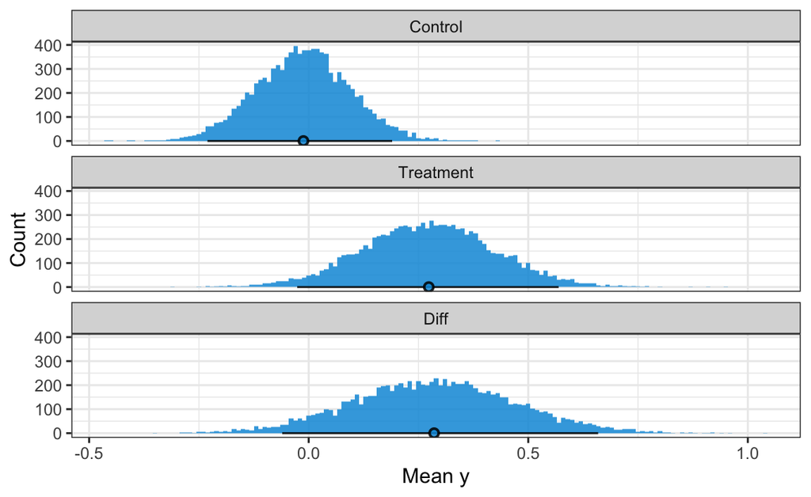

```r
ggplot() +
  theme_bw() +
  facet_wrap(~variable, nrow = 3) +
  geom_histogram(
    data = boot,
    mapping = aes(x = value), binwidth = 0.01) +
  geom_pointrange(
    data = boot_sum,
    mapping = aes(x = y, xmin = ymin, xmax = ymax, y = 0),
    colour = "#000000") +
  labs(y = "Count", x = "Mean y")
```